# 02_modelFitting_globalForestModel

### Show model RMSE w/in each quantile

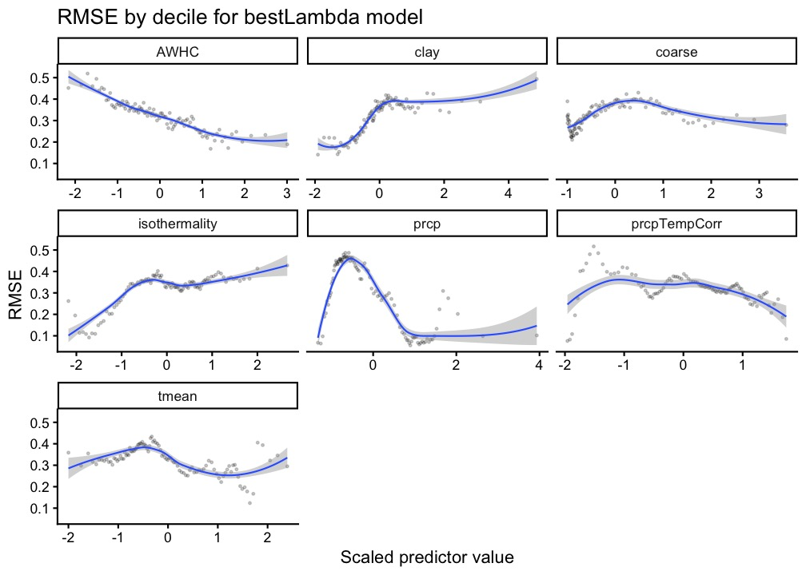

```r
# get deciles for best lambda model
if (length(prednames_fig) == 0) {
  print("The best lambda model only contains one predictor (an intercept), so decile plots aren't possible to generate")
} else {
  pred_glm1_deciles %>%
    ggplot(aes(x = mean_value, y = RMSE)) +
    facet_wrap(~name, scales = "free_x") +
    geom_point(alpha = .2, size = .5) +
    geom_smooth(lwd = .5) +
    xlab("Scaled predictor value") +
    ggtitle("RMSE by decile for bestLambda model")
}
```

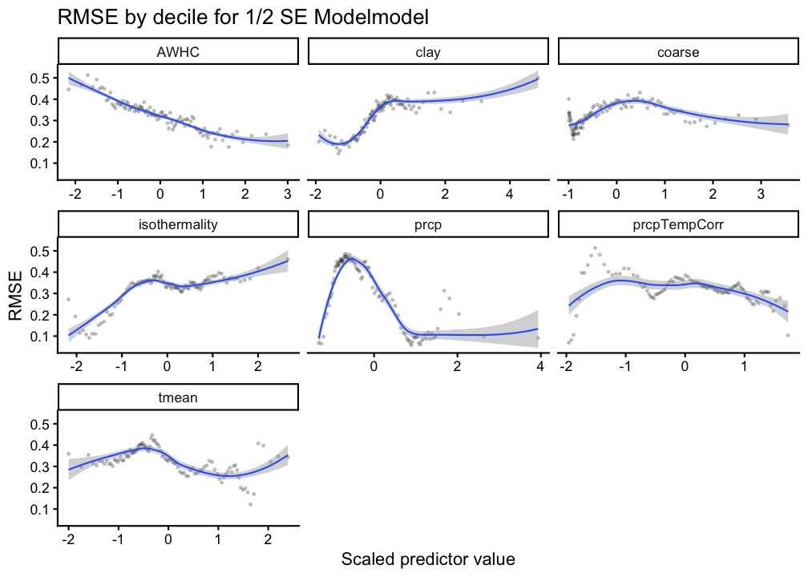

```r
# get deciles for 1 SE lambda model
if (length(prednames_secondBestMod) == 0) {
  print("The 1SE (or 1/2 SE) lambda model only contains one predictor (an intercept), so decile plots aren't possible to generate")
} else {
  pred_glm1_deciles_1se %>%
    ggplot(aes(x = mean_value, y = RMSE)) +
    facet_wrap(~name, scales = "free_x") +
    geom_point(alpha = .2, size = .5) +
    geom_smooth(lwd = .5) +
    xlab("Scaled predictor value") +
    ggtitle(paste0("RMSE by decile for ", name_secondBestMod, "model"))
}
```

## Equations for final models

```r
# get the parameters that were used to scale the data
scaleParams <- modDat_1_s_temp %>%
  filter(Year == 2016) %>%
  dplyr::select(tmin_s:AWHC_s) %>%
  reframe(across(all_of(names(.)), attributes))

# function for printing model statement
## function to get model statements
getModelStatement <- function(coefficientTable, # name of the d.f that has model coefficients
                  modelName, # name of the column in the coefficient table that has the parameters of interest
                  responseVar # name of the response variable
                  ) {
  ##
  # coefficientTable <- grassShrub_totalHerb_trimAnoms
  # modelName <- "coefficientValue_bestLambda"
  # responseVar <- "TotalHerbaceousCover"
  ##
  temp <- coefficientTable[,c("coefficientName", modelName)] %>%
    drop_na()
  rownames(temp) <- temp$coefficientName
  temp[,modelName] <- round(temp[,modelName], 8)

  # print out coefficients w/ coefficient names
tempNames <- paste0(
  apply(temp, MARGIN = 1, FUN = function(x) {
    if (x["coefficientName"] == "(Intercept)") {
      paste0(x[modelName])
    } else {
      paste0(x[modelName], "*", x["coefficientName"])
    }
    }
  ),
  collapse = " + "
)

# print the unscaled model statement
  unscaledModelName <- paste0(responseVar, "~ 1/(1 + exp(-(", tempNames, ")))")

  # now add in the scale parameters
tempNames <- str_replace_all(tempNames, pattern = "annWetDegDays_anom",
                         replacement = paste0("((annWetDegDays_anom - ",
                                              round(scaleParams$annWetDegDays_anom_s$`scaled:center`,8), ") / ",
                                              round(scaleParams$annWetDegDays_anom_s$`scaled:scale`,8), ")"))

tempNames <- str_replace_all(tempNames, pattern = "prcpTempCorr_anom",
                         replacement = paste0("((prcpTempCorr_anom - ",
                                              round(scaleParams$prcpTempCorr_anom_s$`scaled:center`,8), ") / ",
                                              round(scaleParams$prcpTempCorr_anom_s$`scaled:scale`,8), ")"))


tempNames <- str_replace_all(tempNames, pattern = "prcp_seasonality_anom",
                         replacement = paste0("((prcp_seasonality_anom - ",
                                              round(scaleParams$prcp_seasonality_anom_s$`scaled:center`,8), ") / ",
                                              round(scaleParams$prcp_seasonality_anom_s$`scaled:scale`,8), ") "))

tempNames <- str_replace_all(tempNames, pattern = "annWatDef_anom",
                         replacement = paste0("((annWatDef_anom - ",
                                              round(scaleParams$annWatDef_anom_s$`scaled:center`,8), ") / ",
                                              round(scaleParams$annWatDef_anom_s$`scaled:scale`,8), ") "))

tempNames <- str_replace_all(tempNames, pattern = "isothermality_anom",
                         replacement = paste0("((isothermality_anom - ",
                                              round(scaleParams$isothermality_anom_s$`scaled:center`,8), ") / ",
                                              round(scaleParams$isothermality_anom_s$`scaled:scale`,8), ") "))

tempNames <- str_replace_all(tempNames, pattern = "prcp_anom",
                         replacement = paste0("((prcp_anom - ",
                                              round(scaleParams$prcp_anom_s$`scaled:center`,8), ") / ",
                                              round(scaleParams$prcp_anom_s$`scaled:scale`,8), ") "))

tempNames <- str_replace_all(tempNames, pattern = "prcp ",
                         replacement = paste0("((prcp - ",
                                              round(scaleParams$prcp_s$`scaled:center`,8), ") / ",
                                              round(scaleParams$prcp_s$`scaled:scale`,8), ") "))

tempNames <- str_replace_all(tempNames, pattern = "prcp\\^",
                         replacement = paste0("((prcp - ",
                                              round(scaleParams$prcp_s$`scaled:center`,8), ") / ",
                                              round(scaleParams$prcp_s$`scaled:scale`,8), ")^"))

tempNames <- str_replace_all(tempNames, pattern = "prcp:",
                         replacement = paste0("((prcp - ",
                                              round(scaleParams$prcp_s$`scaled:center`,8), ") / ",
                                              round(scaleParams$prcp_s$`scaled:scale`,8), "):"))

tempNames <- str_replace_all(tempNames, pattern = "prcpTempCorr ",
                         replacement = paste0("((prcpTempCorr - ",
                                              round(scaleParams$prcpTempCorr_s$`scaled:center`,8), ") / ",
                                              round(scaleParams$prcpTempCorr_s$`scaled:scale`,8), ") "))

tempNames <- str_replace_all(tempNames, pattern = "prcpTempCorr\\^",
                         replacement = paste0("((prcpTempCorr - ",
                                              round(scaleParams$prcpTempCorr_s$`scaled:center`,8), ") / ",
                                              round(scaleParams$prcpTempCorr_s$`scaled:scale`,8), ")^"))

tempNames <- str_replace_all(tempNames, pattern = "prcpTempCorr:",
                         replacement = paste0("((prcpTempCorr - ",
                                              round(scaleParams$prcpTempCorr_s$`scaled:center`,8), ") / ",
                                              round(scaleParams$prcpTempCorr_s$`scaled:scale`,8), "):"))

tempNames <- str_replace_all(tempNames, pattern = "prcpTempCorr\\)",
                         replacement = paste0("((prcpTempCorr - ",
                                              round(scaleParams$prcpTempCorr_s$`scaled:center`,8), ") / ",
                                              round(scaleParams$prcpTempCorr_s$`scaled:scale`,8), "))"))

tempNames <- str_replace_all(tempNames, pattern = "prcpTempCorr$",
                         replacement = paste0("((prcpTempCorr - ",
                                              round(scaleParams$prcpTempCorr_s$`scaled:center`,8), ") / ",
                                              round(scaleParams$prcpTempCorr_s$`scaled:scale`,8), ")"))
```

```r
tempNames <- str_replace_all(tempNames, pattern = "isothermality ",
                         replacement = paste0("((isothermality - ",
                                              round(scaleParams$isothermality_s$`scaled:center`,8), ") / ",
                                              round(scaleParams$isothermality_s$`scaled:scale`,8), ") "))

tempNames <- str_replace_all(tempNames, pattern = "isothermality\\^",
                         replacement = paste0("((isothermality - ",
                                              round(scaleParams$isothermality_s$`scaled:center`,8), ") / ",
                                              round(scaleParams$isothermality_s$`scaled:scale`,8), ")^"))

tempNames <- str_replace_all(tempNames, pattern = "isothermality:",
                         replacement = paste0("((isothermality - ",
                                              round(scaleParams$isothermality_s$`scaled:center`,8), ") / ",
                                              round(scaleParams$isothermality_s$`scaled:scale`,8), "):"))

tempNames <- str_replace_all(tempNames, pattern = "sand",
                         replacement = paste0("((sand - ",
                                              round(scaleParams$sand_s$`scaled:center`,8), ") / ",
                                              round(scaleParams$sand_s$`scaled:scale`,8), ")"))

tempNames <- str_replace_all(tempNames, pattern = "coarse",
                         replacement = paste0("((coarse - ",
                                              round(scaleParams$coarse_s$`scaled:center`,8), ") / ",
                                              round(scaleParams$coarse_s$`scaled:scale`,8), ")"))

tempNames <- str_replace_all(tempNames, pattern = "AWHC",
                         replacement = paste0("((AWHC - ",
                                              round(scaleParams$AWHC_s$`scaled:center`,8), ") / ",
                                              round(scaleParams$AWHC_s$`scaled:scale`,8), ")"))

tempNames <- str_replace_all(tempNames, pattern = "carbon",
                         replacement = paste0("((carbon - ",
                                              round(scaleParams$carbon_s$`scaled:center`,8), ") / ",
                                              round(scaleParams$carbon_s$`scaled:scale`,8), ")"))

tempNames <- str_replace_all(tempNames, pattern = "clay",
                         replacement = paste0("((clay - ",
                                              round(scaleParams$clay_s$`scaled:center`,8), ") / ",
                                              round(scaleParams$clay_s$`scaled:scale`,8), ")"))

tempNames <- str_replace_all(tempNames, pattern = "annWatDef ",
                         replacement = paste0("((annWatDef - ",
                                              round(scaleParams$annWatDef_s$`scaled:center`,8), ") / ",
                                              round(scaleParams$annWatDef_s$`scaled:scale`,8), ") "))

tempNames <- str_replace_all(tempNames, pattern = "annWatDef:",
                         replacement = paste0("((annWatDef - ",
                                              round(scaleParams$annWatDef_s$`scaled:center`,8), ") / ",
                                              round(scaleParams$annWatDef_s$`scaled:scale`,8), "):"))

tempNames <- str_replace_all(tempNames, pattern = "prcp_seasonality ",
                         replacement = paste0("((prcp_seasonality - ",
                                              round(scaleParams$prcp_seasonality_s$`scaled:center`,8), ") / ",
                                              round(scaleParams$prcp_seasonality_s$`scaled:scale`,8), ") "))

tempNames <- str_replace_all(tempNames, pattern = "prcp_seasonality:",
                         replacement = paste0("((prcp_seasonality - ",
                                              round(scaleParams$prcp_seasonality_s$`scaled:center`,8), ") / ",
                                              round(scaleParams$prcp_seasonality_s$`scaled:scale`,8), "):"))

tempNames <- str_replace_all(tempNames, pattern = "prcp_seasonality\\^",
                         replacement = paste0("((prcp_seasonality - ",
                                              round(scaleParams$prcp_seasonality_s$`scaled:center`,8), ") / ",
                                              round(scaleParams$prcp_seasonality_s$`scaled:scale`,8), ")^"))

tempNames <- str_replace_all(tempNames, pattern = "tmean ",
                         replacement = paste0("((tmean - ",
                                              round(scaleParams$tmean_s$`scaled:center`,8), ") / ",
                                              round(scaleParams$tmean_s$`scaled:scale`,8), ") "))

tempNames <- str_replace_all(tempNames, pattern = "tmean:",
                         replacement = paste0("((tmean - ",
                                              round(scaleParams$tmean_s$`scaled:center`,8), ") / ",
                                              round(scaleParams$tmean_s$`scaled:scale`,8), "):"))

tempNames <- str_replace_all(tempNames, pattern = "tmean$",
                         replacement = paste0("((tmean - ",
                                              round(scaleParams$tmean_s$`scaled:center`,8), ") / ",
                                              round(scaleParams$tmean_s$`scaled:scale`,8), ")"))

tempNames <- str_replace_all(tempNames, pattern = "tmean\\^",
                         replacement = paste0("((tmean - ",
                                              round(scaleParams$tmean_s$`scaled:center`,8), ") / ",
                                              round(scaleParams$tmean_s$`scaled:scale`,8), ")^"))

tempNames <- str_replace_all(tempNames, pattern = "annWetDegDays ",
                         replacement = paste0("((annWetDegDays - ",
                                              round(scaleParams$annWetDegDays_s$`scaled:center`,8), ") / ",
                                              round(scaleParams$annWetDegDays_s$`scaled:scale`,8), ") "))
```

```r
tempNames <- str_replace_all(tempNames, pattern = "annWetDegDays:",
                         replacement = paste0("((annWetDegDays - ",
                                              round(scaleParams$annWetDegDays_s$`scaled:center`,8), ") / ",
                                              round(scaleParams$annWetDegDays_s$`scaled:scale`,8), "):"))

tempNames <- str_replace_all(tempNames, pattern = "prcp_dry ",
                         replacement = paste0("((prcp_dry - ",
                                              round(scaleParams$prcp_dry_s$`scaled:center`,8), ") / ",
                                              round(scaleParams$prcp_dry_s$`scaled:scale`,8), ") "))

tempNames <- str_replace_all(tempNames, pattern = "prcp_dry:",
                         replacement = paste0("((prcp_dry - ",
                                              round(scaleParams$prcp_dry_s$`scaled:center`,8), ") / ",
                                              round(scaleParams$prcp_dry_s$`scaled:scale`,8), "):"))

tempNames <- str_replace_all(tempNames, pattern = "annWatDef_95",
                         replacement = paste0("((annWatDef_95 - ",
                                              round(scaleParams$annWatDef_95_s$`scaled:center`,8), ") / ",
                                              round(scaleParams$annWatDef_95_s$`scaled:scale`,8), ")"))


## print scaled model statement

scaledModelName <- paste0(responseVar, "~ exp(", tempNames, ")")

return(list("scaledInputVars_ModelStatement" = unscaledModelName,
            "unscaledInputVars_scaledModelStatement" = scaledModelName))
}


## bestLambda model equations
bestLambdaModStatement <- getModelStatement(coefficientTable = coefs,
                  modelName = "coefficientValue_bestLambda",
                  responseVar = "P(Forest)")
## second-best lambda model equations
secondBestLambdaModStatement <- getModelStatement(coefficientTable = coefs,
                  modelName = ifelse(name_secondBestMod == "1/2 SE Model",
                                      yes = "coefficientValue_halfseLambda",
                                     no = "coefficientValue_1seLambda"),
                  responseVar = "P(Forest)")
```

#### The equation for the bestLambda model if the inputs *are* scaled is:

```r
print(bestLambdaModStatement$scaledInputVars_ModelStatement)
```

```
## [1] "P(Forest)~ 1/(1 + exp(-( 3.38565522 + -0.79822221*tmean +  4.74536062*prcp + -0.49798680*prcpTempCorr +  0.22745494*isothermality + -0.39051271*clay +  0.53857137*coarse + -0.40059849*AWHC + -0.83406990*I(prcp^2) + -0.94850342*I(prcpTempCorr^2) +  0.19450621*I(isothermality^2) + -0.04772718*…
```

#### The equation for the *second*-bestLambda model if the inputs *are* scaled is:

```r
print(secondBestLambdaModStatement$scaledInputVars_ModelStatement)
```

```
## [1] "P(Forest)~ 1/(1 + exp(-( 3.42280818 + -0.67004117*tmean +  4.64682091*prcp + -0.51478088*prcpTempCorr + -0.39361729*clay +  0.57046745*coarse + -0.43214019*AWHC + -0.81467937*I(prcp^2) + -0.96053569*I(prcpTempCorr^2) +  0.28596197*I(isothermality^2) + -0.04690744*I(clay^2) + -0.26903003*I(co…
```

## Now, use the model to predict if a location is or is not trees, for all observations in the cover dataset (which we will use in the subsequent step of the cover-modeling process).

We use the ‘modDat_1_s_temp’ data.frame, which has all of the cover data, even for locations without observed tree cover, but has the climate and soils data that have been scaled in that same was as the data we used to fit the yes/no tree model

```r
# prep data
modDat_1_s_temp$rowID <- 1:nrow(modDat_1_s_temp)
predData <- modDat_1_s_temp %>%
  select(rowID, Year, x, y, paste0(prednames, "_s")) %>%
  rename_with(~str_remove(.x, "_s$"),
              any_of(paste0(names(prednames), "_s")))
# for bestLambda model
predData$treeProb_bestLambda <- predict.glm(object = fit_glm_bestLambda, newdata = predData, type = "response")
# for scond-bestLambda model
predData$treeProb_secondBestLambda <- predict.glm(object = mod_secondBest, newdata = predData, type = "response")


# make continuous predictions binary according to the identified best threshold for each model
predData <- predData %>%
  mutate(treeProb_bestLambda_continuous = approxfun_bestLambda(treeProb_bestLambda)) %>% # use interpolation to shift the continuous values
  mutate(treeProb_bestLambda_continuous = replace(treeProb_bestLambda_continuous, list = treeProb_bestLambda < 0, 0)) %>% # replace NAs at the 'bottom' of the interpolation scale with 0s
  mutate(treeProb_bestLambda_binary = treeProb_bestLambda_continuous,
    treeProb_bestLambda_binary = replace(treeProb_bestLambda_binary, treeProb_bestLambda_binary > 0.1, 1), # now, make the interpolated continuous model predictions binary
         treeProb_bestLambda_binary = replace(treeProb_bestLambda_binary, treeProb_bestLambda_binary <= 0.1, 0))

# add predictions back to the original data frame and save
modDat_treePreds <- modDat_1_s_temp %>%
  left_join(predData %>% select(-c(tmean:AWHC)), by = c("rowID", "Year", "x", "y")) %>%
  select(-c(tmin_s:AWHC_s))

saveRDS(modDat_treePreds,"../../../Data_processed/CoverData/CoverModelData_withTreeNoTreePreds.rds")
```